# RNASeq

#### Individual Pathway Expression Heatmaps

For each significant pathway, we generate Z-score normalized heatmaps showing the expression of all leading-edge genes across conditions. Genes are hierarchically clustered to reveal co-expression patterns.

We also generate category_plots showing average expression patterns of leading-edge genes grouped by pathway categories defined earlier. Each category plot includes a boxplot of individual gene expressions alongside the mean pathway expression trends.

```r
# Loop through all categories using map to run plot_expression_by_category()
category_plots <- map(
  unique(pathway_groups_HALLMARK$category),
  ~ {
    plot_obj <- plot_expression_by_category(
      pathway_groups = pathway_groups_HALLMARK,
      category_name = .x,
      leading_edges = le_genes_VirusEffect_diff_vsNB$grouped_leading_edge,
      vst_matrix = vst_matrix,
      meta = meta
    )

    # Combine boxplot and main plot side by side
    combined_plot <- ggarrange(
      plot_obj$boxplot,
      plot_obj$plot,
      ncol = 2,
      widths = c(1, 1)
    )

    # Add title using annotate_figure
    annotate_figure(combined_plot, top = text_grob(.x, face = "bold", size = 18))

  }
)

# Create a combined multi-page PDF with all plots
CairoPDF(file = file.path(outputs_folder, paste0("GSEA_VirusEffectDiff_GenSets_LE.pdf")),
         width = 15, height = 6)
walk(category_plots, ~ print(.x))
dev.off()
```

#### Custom Pathway Selection: Key Biological Processes

**Note:** This visualization uses `all_leading_edge`, meaning genes that are leading-edge members of multiple selected pathways will be included for each pathway they contribute to, providing a complete view of pathway membership.

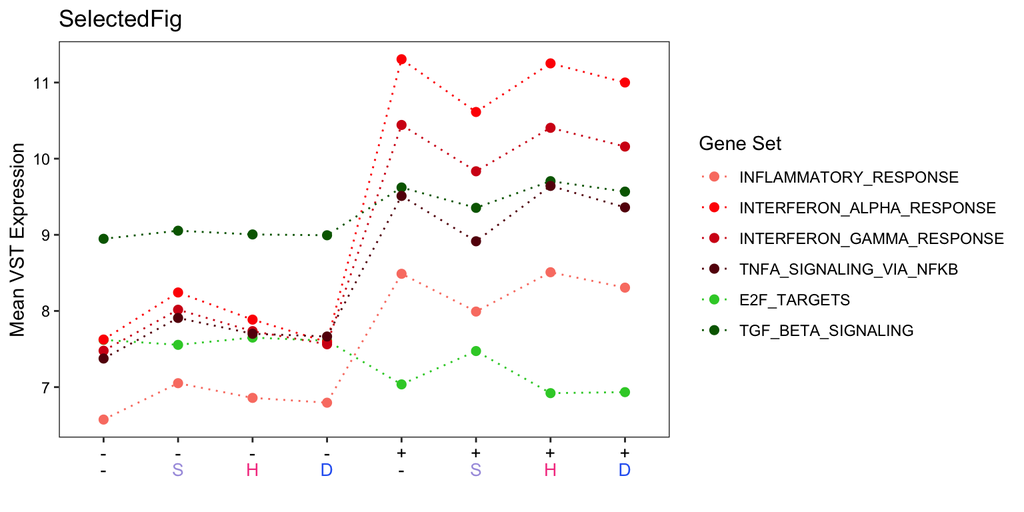

```r
# We select specific gen sets to plot together with genes that are LE in more than one pathway plotted duplicated as needed.
pathway_groups_selected <- bind_rows(
  tibble(
    pathway = c("INFLAMMATORY_RESPONSE", "INTERFERON_ALPHA_RESPONSE",
                "INTERFERON_GAMMA_RESPONSE", "TNFA_SIGNALING_VIA_NFKB",
                "E2F_TARGETS", "TGF_BETA_SIGNALING"),
    category = "SelectedFig",
    color = "grey"
  )
)
colors_groups_selected <- c("#FA8072", "#FF0000", "#D40118", "#65000b", "#32CD32", "#006400")


# Loop through all categories using map to run plot_expression_by_category()
selected_gene_sets <- map(
  unique(pathway_groups_selected$category),
  ~ {
    plot_obj <- plot_expression_by_category(
      pathway_groups = pathway_groups_selected,
      pathway_colors = colors_groups_selected,
      category_name = .x,
      leading_edges = le_genes_VirusEffect_diff_vsNB$all_leading_edge,
      vst_matrix = vst_matrix,
      meta = meta
    )

    # Save combined plot as PDF
    ggsave(
      filename = paste0(outputs_folder, "/GSEA_VirusEffectDiff_LE_", .x, ".png"),
      plot = plot_obj$plot,
      width = 8, height = 4, dpi = 300
    )

   # Save plot object as RDS
    saveRDS(
      plot_obj$plot,
      file = paste0(outputs_folder, "/GSEA_VirusEffectDiff_LE_", .x, ".rds")
    )

    plot_obj$plot  # Return combined plot for reference
  }
)

selected_gene_sets[[1]]
```

```r
# For those same gene sets we generate individual Z-score heatmaps and save them as one object
selected_gene_sets <- map(
  unique(pathway_groups_selected$pathway),
  ~ {
    plot_obj <- plot_expression_by_pathway(
      pathway_name = .x,
      leading_edges = le_genes_VirusEffect_diff_vsNB$all_leading_edge,
      vst_matrix = vst_matrix,
      meta = meta
    )
    return(list(plot = plot_obj$heatmap_Z,
                n_rows = n_distinct(plot_obj$heatmap_data$Gene)
    ))
  }
)

# Name the list elements by pathway
names(selected_gene_sets) <- pathway_groups_selected$pathway

# Save the entire list as well for easy access
saveRDS(selected_gene_sets, file = file.path(outputs_folder, "GSEA_VirusEffectDiff_ZHeatmaps_SelectedFig.rds"))
```

```r
# For each pathway, calculate mean expression of leading-edge genes and perform mixed-effects modeling
analyze_pathway_mean_expression <- function(pathway_name, leading_edges,
                                           vst_matrix, meta) {

  # Get all genes in this pathway's leading edge
  pathway_genes <- leading_edges %>%
    filter(pathway == pathway_name) %>%
    pull(gene)

  # Get expression values and calculate mean per sample
  expression_df <- vst_matrix[pathway_genes, ] %>%
    as.data.frame() %>%
    rownames_to_column("Gene") %>%
    pivot_longer(-Gene, names_to = "Sample", values_to = "Expression") %>%
    left_join(meta, by = c("Sample" = "label")) %>%
    group_by(Sample, condition, Bac.Vir_label, Bac.Vir_label_symbols,
             species, virus, line, date) %>%
    summarise(MeanExpression = mean(Expression, na.rm = TRUE),
              .groups = "drop") %>%
    mutate(pathway = pathway_name)

  # Fit mixed-effects model
  model <- lmer(MeanExpression ~ condition + (1|line) + (1|line:date),
                data = expression_df)

  # Check for singularity
  singular <- isSingular(model)
  if (singular) {
    model <- lmer(MeanExpression ~ condition + (1|date),
                  data = expression_df)
  }

  # Get ANOVA results
  anova_result <- anova(model)
  anova_pval <- anova_result$`Pr(>F)`[1]

  # Extract random effects
  random_effects_df <- as.data.frame(VarCorr(model)) %>%
    mutate(proportion = round(100 * (vcov / sum(vcov)), 2),
           singular = singular,
           pathway = pathway_name)

  # Extract fixed effects
  fixed_effects_df <- as.data.frame(summary(model)$coefficients) %>%
    rownames_to_column(var = "term") %>%
    mutate(pathway = pathway_name)

  # Get emmeans contrasts vs NB.NV with Holm adjustment
  emmeans_model <- emmeans(model, ~ condition)
  contrasts <- pairs(emmeans_model, adjust = "none")

  contrast_df <- as.data.frame(summary(contrasts)) %>%
    separate(contrast, into = c("condition1", "condition2"),
             sep = " - ", remove = FALSE) %>%
    mutate(pathway = pathway_name,
           anova_pval = anova_pval)

  return(list(
    expression_data = expression_df,
    anova = anova_result,
    random_effects = random_effects_df,
    fixed_effects = fixed_effects_df,
    contrasts = contrast_df
  ))
}
```

```r
# Analyze all pathways
pathway_stats_list <- map(
  pathway_groups_selected$pathway,
  ~ analyze_pathway_mean_expression(
    pathway_name = .x,
    leading_edges = le_genes_VirusEffect_diff_vsNB$grouped_leading_edge,
    vst_matrix = vst_matrix,
    meta = meta
  )
)
names(pathway_stats_list) <- pathway_groups_selected$pathway

# Combine all contrasts
selected_gene_sets_contrasts <- bind_rows(
  map(pathway_stats_list, "contrasts"),
  .id = "pathway"
) %>%
  mutate(across(where(is.character), as.factor))

# Adjust across all contrasts
selected_gene_sets_contrasts <- selected_gene_sets_contrasts %>%
  mutate(adj.p.FDR = p.adjust(p.value, method = "fdr")) %>%
  mutate(sign.FDR = ifelse(adj.p.FDR < 0.05, T, F)) %>%
  mutate(sign = case_when(
    adj.p.FDR < 0.05 ~ "*",
    TRUE ~ ""
  ))

selected_gene_sets_contrasts$adj.p.FDR = format(selected_gene_sets_contrasts$adj.p.FDR, digits = 2, scientific = TRUE)

write_csv(selected_gene_sets_contrasts, file.path(outputs_folder, "GSEA_VirusEffectDiff_LE_Selected_statistics.csv"))
saveRDS(selected_gene_sets_contrasts, file.path(outputs_folder, "GSEA_VirusEffectDiff_LE_Selected_statistics.rds"))
```

## CONTENTO SummarizedExperiment

To allow interactive exploration of these results, we packaged the final DESeq2 model into a SummarizedExperiment (SE) object for CONTENTO ([doi:10.5281/zenodo.21629492](https://doi.org/10.5281/zenodo.21629492)), a Shiny app for exploring differential expression results across multiple contrasts. The SE was built following CONTENTO’s [Create SE tutorial](https://klemonlab.github.io/CONTENTO/create-se-file.html) and contains all contrasts from Combine all contrast results, the VST matrix as the `expr_matrix` assay, and the sample metadata. Setting `organism = "Homo sapiens"` enables MSigDB gene set enrichment in CONTENTO, and the built-in `Homo_sapiens.GRCh38.113_annot` annotation (Ensembl release 113, the same used here) adds gene names to the Ensembl IDs.

The `convert_to_SE()` function is copied from the CONTENTO tutorial:

```r
convert_to_SE <- function(dds, contrasts_df, expr_matrix,
                          organism = NULL, annotation = NULL, varpart = NULL,
                          db_species = NULL, dataset_name = NULL) {

  # Reshape to wide format
  contrasts_wide <- contrasts_df %>%
    pivot_wider(
      id_cols = Geneid,
      names_from = contrast,
      values_from = -c(Geneid, contrast),
      names_sep = "__"
    )

  contrasts_found <- unique(contrasts_df$contrast)
  cat("✓ Found", length(contrasts_found), "contrasts:", paste(contrasts_found, collapse = ", "), "\n")

  # Extract sample metadata
  sample_metadata <- as.data.frame(colData(dds))

  # Create rowData with Geneid as rownames
  rowdata_df <- contrasts_wide %>%
    column_to_rownames("Geneid")

  # Add variance partition data if provided
  if (!is.null(varpart)) {
    cat("Loading variance partition data...\n")

    tryCatch({
      # Extract only the variance partition matrix
      varpart_matrix <- varpart$varPart

      # Get common genes between rowData and varPart
      common_genes <- intersect(rownames(rowdata_df), rownames(varpart_matrix))

      if (length(common_genes) > 0) {
        # Convert to dataframe and add varpart_ prefix
        varpart_df <- as.data.frame(varpart_matrix[common_genes, , drop = FALSE])
        colnames(varpart_df) <- paste0("varpart_", colnames(varpart_df))

        # Merge with rowdata_df (only for genes that exist in both)
        rowdata_df[common_genes, colnames(varpart_df)] <- varpart_df

        cat("✓ Added variance partition for", length(common_genes), "genes\n")
        cat("  Factors:", paste(gsub("varpart_", "", colnames(varpart_df)), collapse = ", "), "\n")
      } else {
        cat("⚠ No common genes between contrasts and variance partition\n")
      }

    }, error = function(e) {
      cat("⚠ Error loading variance partition:", e$message, "\n")
    })
  }

  # Ensure rowData order matches dds
  rowdata_df <- rowdata_df[rownames(dds), ]

  # Verify dimensions match
  stopifnot(identical(rownames(rowdata_df), rownames(dds)))
  stopifnot(identical(rownames(sample_metadata), colnames(dds)))

  cat("✓ Gene order verified:", nrow(rowdata_df), "genes match\n")

  # Create SummarizedExperiment
  se <- SummarizedExperiment(
    assays = list(expr_matrix = expr_matrix),
    colData = DataFrame(sample_metadata),
    rowData = DataFrame(rowdata_df)
  )

  # Store metadata
  metadata(se) <- list(
    design = design(dds),
    contrasts = contrasts_found,
    organism = organism,
    annotation = annotation,
    db_species = db_species,      # optional: "HS" or "MM", overrides automatic msigdbr routing
    dataset_name = dataset_name,  # optional: base filename prefix for CONTENTO downloads
    date = Sys.Date()             # recorded for reproducibility but not read by CONTENTO itself
  )

  # Return the SummarizedExperiment object

  cat("  Dimensions:", nrow(se), "genes x", ncol(se), "samples\n")
  cat("  Assays:", paste(names(assays(se)), collapse = ", "), "\n")
  cat("  Columns in rowData:", ncol(rowData(se)), "\n\n")

  return(se)
}
```

CONTENTO requires generic column names (`log2FC`, `stat`, `padj` and, optionally, `log2FC_shrunk`), so we keep only those statistics from `DESeqData`. Genes with zero counts in all samples have no results and are not in `DESeqData`, so we subset `dds` and the VST matrix to the genes with results.

```r
# Keep and rename the statistics CONTENTO uses
contrasts_SE <- DESeqData %>%
  dplyr::select(Geneid, contrast, log2FoldChange, log2FoldChange_shrunk, stat, padj) %>%
  dplyr::rename(log2FC = log2FoldChange, log2FC_shrunk = log2FoldChange_shrunk)

# Genes with results
genes_SE <- unique(contrasts_SE$Geneid)

# Build the SE
SE <- convert_to_SE(
  dds = dds[genes_SE, ],
  contrasts_df = contrasts_SE,
  expr_matrix = vst_matrix[genes_SE, ],
  organism = "Homo sapiens",
  annotation = "Homo_sapiens.GRCh38.113_annot",
  dataset_name = "RSVBac"
)
```

```
✓ Found 14 contrasts: VirusTvsF_NB, VirusTvsF_Spn, VirusTvsF_Hin, VirusTvsF_Dpi, VirusEffectDiff_Spn, VirusEffectDiff_Hin, VirusEffectDiff_Dpi, SpnvsNB_VF, HinvsNB_VF, DpivsNB_VF, SpnvsNB_VT, HinvsNB_VT, DpivsNB_VT, Line_9009_vs_9007
✓ Gene order verified: 78932 genes match
  Dimensions: 78932 genes x 40 samples
  Assays: expr_matrix
  Columns in rowData: 56
```

```r
saveRDS(SE, file = file.path(outputs_folder, paste0(dataframeID, "_RNASeq_human_SE.rds")))
```